# MY472 - Assignment 2

## Native languages in Finland’s biggest municipalities

For this exercise, I will be looking at data on the 15 biggest municipalities in Finland, available from Finland’s English Wikipedia article. The initial data comes from a table with the 15 largest municipalities by population, under the ‘Administrative divisions’ section. Along with the data from the table, each individual municipality page was visited. From these pages, the proportion of inhabitants that had Finnish, Swedish, or Other as their native language was scraped and added to the table. The code for this process is presented below:

```r
library(gridExtra)
```

```r
# Get initial url and read
finland_url <- 'https://en.wikipedia.org/wiki/Finland'
fin_html <- read_html(finland_url)

# Get table with municipality data
table <- fin_html %>% html_element(xpath = '//*[@id="mw-content-text"]/div[1]/table[3]') %>%
  html_table(fill = TRUE)

# Get links from table
# In this case, end of link to certain page, e.g. /wiki/Helsinki
links <- fin_html %>%
  html_element(xpath = '//*[@id="mw-content-text"]/div[1]/table[3]') %>%
  html_elements(xpath = '//td/b/a') %>%
  html_attr('href')

# Make emtpy data frame to fill with language data
# Loop over links save d from before
native_lang <- data.frame()
for(city in links) {
  # url is wikipedia + link ending from vector
  url <- paste('https://en.wikipedia.org', city, sep = '')
  city_html <- read_html(url)

  # Get the text from the sidebar on the right with municipality info
  texty <- city_html %>%
  html_element(xpath = '//*[contains(concat( " ", @class, " " ), concat( " ", "vcard", " " ))]') %>%
  html_elements(xpath = '//*[contains(concat( " ", @class, " " ), concat( " ", "infobox-data", " " ))]') %>%
  html_text()

  # The only item with the word 'official' in it is the Finnish language one
  # Thus, we select that element and the following 2 (Swedish + Other)
  # This is added to the language df
  native_lang <- rbind(native_lang, texty[which(grepl('official', texty)):(which(grepl('official', texty))+2)])

  Sys.sleep(2)

}

# Add languages to the table
table <- table %>%
  mutate(
    Finnish = native_lang[,1],
    Swedish = native_lang[,2],
    Other = native_lang[,3]
  )

# Cut out middle 2 columns of table containing maps on wikipedia
table <- table[,c(1:4, 7:9)]

# Change column names to be easier to work with
colnames(table) <- c('City', 'Population', 'Land_Area',
                     'Density', 'Finnish', 'Swedish', 'Other')

# Show result
table
```

```
## # A tibble: 15 × 7
##    City         Population Land_Area Density  Finnish          Swedish Other
##    <chr>        <chr>      <chr>     <chr>    <chr>            <chr>   <chr>
##  1 Helsinki     656,250    213.75    3,070.18 84.3% (official) 6.1%    9.6%
##  2 Espoo        293,576    312.26    940.17   83.6% (official) 8.3%    8%
##  3 Tampere      241,672    525.03    460.3    94.9% (official) 0.5%    4.5%
##  4 Vantaa       238,033    238.37    998.59   88.6% (official) 3%      8.4%
##  5 Oulu         207,717    1,410.17  147.3    97.3% (official) 0.2%    2.4%
##  6 Turku        194,244    245.67    790.67   88.1% (official) 5.2%    6.7%
##  7 Jyväskylä    143,400    1,170.99  122.46   96.7% (official) 0.2%    3%
##  8 Kuopio       120,248    1,597.39  75.28    97.8% (official) 0.1%    2.1%
##  9 Lahti        120,112    459.47    261.41   95.7% (official) 0.3%    4%
## 10 Pori         83,676     834.06    100.32   98% (official)   0.5%    1.5%
## 11 Kouvola      81,141     2,558.24  31.72    97.2% (official) 0.4%    2.4%
## 12 Joensuu      76,833     2,381.76  32.26    97.4% (official) 0.1%    2.5%
## 13 Lappeenranta 72,591     1,433.36  50.64    95.9% (official) 0.1%    4%
## 14 Hämeenlinna  67,864     1,785.76  38       97.5% (official) 0.3%    2.2%
## 15 Vaasa        67,447     188.81    357.22   69.8% (official) 24.8%   5.4%
```

Next, the data was cleaned. Comma separators and percentage signs (for languages) were removed. Additionally, the column for Finnish language contained the word ‘official’ within brackets, which was removed. All numerical variables were turned converted to numerical from character. A longer format of the data was created for plotting, by pivoting the data on the language columns such that the frequency data became a variable along with a variable denoting which language the row referred to. The original table was maintained to run some basic hypothesis testing. The code for cleaning is presented below:

```r
# Remove commas, remove percentage signs and spaces
# Remove '(official)' from Finnish language column
# Divide language columns bu 100 to get decimal, not percentage
table_clean <- table %>%
  mutate(Population = as.numeric(str_remove_all(Population, ',')),
         Land_Area = as.numeric(str_remove_all(Land_Area, ',')),
         Density = as.numeric(str_remove_all(Density, ',')),
         Finnish = as.numeric(str_remove_all(Finnish, '\\s|\\(.*\\)|\\%'))/100,
         Swedish = as.numeric(str_remove_all(Swedish, '\\%'))/100,
         Other = as.numeric(str_remove_all(Other, '\\%'))/100)

# Make a long format table for plotting easier
table_long <- table_clean %>%
  pivot_longer(cols = c('Finnish', 'Swedish', 'Other'),
               names_to = 'Language',
               values_to = 'Frequency')
```

To visualize the relationship between municipality size and native language frequency, the population size was plotted against the frequency of Finnish, Swedish and Other speakers on separate axes.

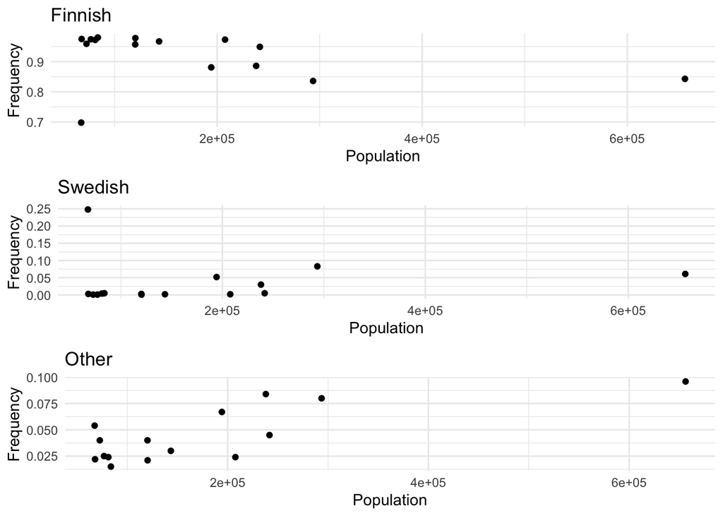

Scatter plots showing the relationship between population size and the frequency of people with Finnish, Swedish or Other as their native language.

```r
# Plot population against finnish, swedish, other
# First make 3 individual plots and add to list
plot_list_p <- list()
i = 1
for(lang in c('Finnish', 'Swedish', 'Other')) {
  plot_list_p[[i]] <- ggplot(table_long[table_long$Language == lang,],
              aes(x = Population, y = Frequency, label = City)) +
  geom_point() +
  labs(title = lang) +
  theme_minimal()

  i <- i + 1
}

# Same for population density
plot_list_d <- list()
i = 1
for(lang in c('Finnish', 'Swedish', 'Other')) {
  plot_list_d[[i]] <- ggplot(table_long[table_long$Language == lang,],
              aes(x = Density, y = Frequency, label = City)) +
  geom_point() +
  labs(title = lang) +
  theme_minimal()

  i <- i + 1
}

# Plot population with grid.arrange, making 3 plots stacked on top of one another
grid.arrange(plot_list_p[[1]],
             plot_list_p[[2]],
             plot_list_p[[3]],
             ncol = 1, nrow = 3,
             widths = 4.5, heights = c(5, 5, 5))
```

The plots show a somewhat negative relationship between the frequency of Finnish native speakers and population size and a positive relationship between frequency of Other languages and population size. To test this, simple linear regressions were run with population size as the predictor and frequency of Finnish, Swedish, and Other native speakers as the target variable. Variables were z-scored to receive standardized beta coefficients. There was no significant relationship between population size and Finnish native speakers ($\beta = -.322 (.263), t = -1.227, p = .242$) or Swedish native speakers ($\beta = .093 (.276), t = .337, p = .742$). There was a significant positive relationship between population size and Other native speakers ($\beta = .754 (.182), t = 4.132, p = .001$). This suggests that larger municipalities in Finland have a higher frequency of individuals whose native tongue is not Finnish or Swedish.

```r
# simple regressions on population and language frequencies
summary(lm(scale(Finnish) ~ scale(Population), data = table_clean))
```

```
##
## Call:
## lm(formula = scale(Finnish) ~ scale(Population), data = table_clean)
##
## Residuals:
##     Min      1Q  Median      3Q     Max
## -3.0376 -0.1467  0.4231  0.4841  0.7042
##
## Coefficients:
##                     Estimate Std. Error t value Pr(>|t|)
## (Intercept)        6.185e-16  2.537e-01   0.000    1.000
## scale(Population) -3.222e-01  2.626e-01  -1.227    0.242
##
## Residual standard error: 0.9824 on 13 degrees of freedom
## Multiple R-squared:  0.1038, Adjusted R-squared:  0.03486
## F-statistic: 1.506 on 1 and 13 DF,  p-value: 0.2416
```

```r
summary(lm(scale(Swedish) ~ scale(Population), data = table_clean))
```

```
##
## Call:
## lm(formula = scale(Swedish) ~ scale(Population), data = table_clean)
##
## Residuals:
##     Min      1Q  Median      3Q     Max
## -0.5018 -0.4497 -0.4007  0.0211  3.3710
##
## Coefficients:
##                     Estimate Std. Error t value Pr(>|t|)
## (Intercept)       -3.567e-17  2.668e-01   0.000    1.000
## scale(Population)  9.305e-02  2.761e-01   0.337    0.742
##
## Residual standard error: 1.033 on 13 degrees of freedom
## Multiple R-squared:  0.008659,   Adjusted R-squared:  -0.0676
## F-statistic: 0.1135 on 1 and 13 DF,  p-value: 0.7415
```

```r
summary(lm(scale(Other) ~ scale(Population), data = table_clean))
```

```
##
## Call:
## lm(formula = scale(Other) ~ scale(Population), data = table_clean)
##
## Residuals:
##     Min      1Q  Median      3Q     Max
## -0.9361 -0.3899 -0.2972  0.5668  1.2204
##
## Coefficients:
##                     Estimate Std. Error t value Pr(>|t|)
## (Intercept)       -7.950e-19  1.762e-01   0.000  1.00000
## scale(Population)  7.535e-01  1.824e-01   4.132  0.00118 **
## ---
## Signif. codes:  0 '***' 0.001 '**' 0.01 '*' 0.05 '.' 0.1 ' ' 1
##
## Residual standard error: 0.6823 on 13 degrees of freedom
## Multiple R-squared:  0.5677, Adjusted R-squared:  0.5345
## F-statistic: 17.07 on 1 and 13 DF,  p-value: 0.001181
```

Next, the same visualizations and models were run for population density and native language frequency. Population density is highly correlated with population size in our sample (Pearson correlation: $r(13) = .955, p < .001$), suggesting differences between outcomes fro population size and density will not be too large. However, this analysis was still run to see if there might be slight nuances in results. From figure 2, we note similar patterns to the population size plots. Finnish native speakers seem to make up a smaller part of the population in more dense municipalities, with no relationship for Swedish speakers and a positive relationship for Other native languages.

```r
cor.test(table_clean$Population, table_clean$Density)
```

```
##
##  Pearson's product-moment correlation
##
## data:  table_clean$Population and table_clean$Density
## t = 11.594, df = 13, p-value = 3.153e-08
## alternative hypothesis: true correlation is not equal to 0
## 95 percent confidence interval:
##  0.8664710 0.9852266
## sample estimates:
##       cor
## 0.9548938
```

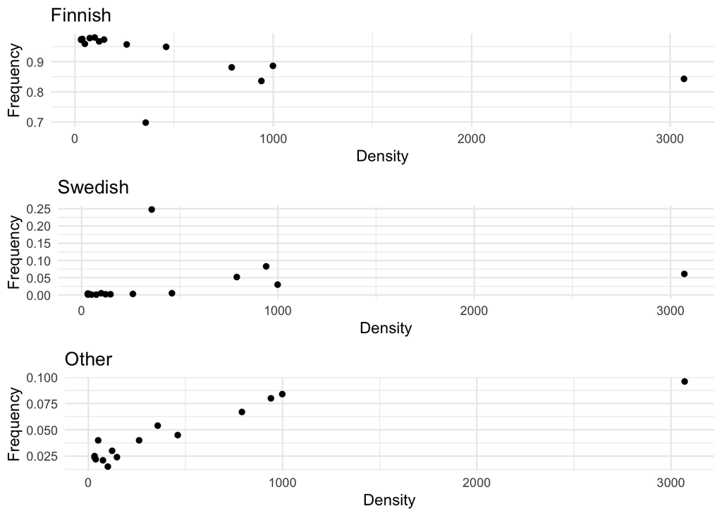

Scatter plots showing the relationship between population density and the frequency of people with Finnish, Swedish or Other as their native language.

```r
# Plot density with grid.arrange, making 3 plots stacked on top of one another
grid.arrange(plot_list_d[[1]],
             plot_list_d[[2]],
             plot_list_d[[3]],
             ncol = 1, nrow = 3,
             widths = 4.5, heights = c(5, 5, 5))
```

Testing this with the same models as for population size, but switching size out for density, we find no significant relationship between Finnish speakers and density ($\beta = -.476 (.245), t = -1.953, p = .073$), no relationship for Swedish speakers ($\beta = .251 (.269), t = .936, p = .367$), but a positive relationship for Other languages ($\beta = .836 (.152), t = 5.49, p < .001$). As expected, these results are qualitatively the same as for population size.

```r
# model population density
summary(lm(scale(Finnish) ~ scale(Density), data = table_clean))
```

```
##
## Call:
## lm(formula = scale(Finnish) ~ scale(Density), data = table_clean)
##
## Residuals:
##      Min       1Q   Median       3Q      Max
## -2.88924  0.02377  0.33775  0.40738  0.56849
##
## Coefficients:
##                  Estimate Std. Error t value Pr(>|t|)
## (Intercept)     5.993e-16  2.356e-01   0.000   1.0000
## scale(Density) -4.763e-01  2.439e-01  -1.953   0.0727 .
## ---
## Signif. codes:  0 '***' 0.001 '**' 0.01 '*' 0.05 '.' 0.1 ' ' 1
##
## Residual standard error: 0.9125 on 13 degrees of freedom
## Multiple R-squared:  0.2268, Adjusted R-squared:  0.1674
## F-statistic: 3.814 on 1 and 13 DF,  p-value: 0.0727
```

```r
summary(lm(scale(Swedish) ~ scale(Density), data = table_clean))
```

```
##
## Call:
## lm(formula = scale(Swedish) ~ scale(Density), data = table_clean)
##
## Residuals:
##     Min      1Q  Median      3Q     Max
## -0.4250 -0.3675 -0.3500 -0.2578  3.3486
##
## Coefficients:
##                  Estimate Std. Error t value Pr(>|t|)
## (Intercept)    -4.313e-17  2.594e-01   0.000    1.000
## scale(Density)  2.512e-01  2.685e-01   0.936    0.367
##
## Residual standard error: 1.004 on 13 degrees of freedom
## Multiple R-squared:  0.06309,    Adjusted R-squared:  -0.008979
## F-statistic: 0.8754 on 1 and 13 DF,  p-value: 0.3665
```

```r
summary(lm(scale(Other) ~ scale(Density), data = table_clean))
```

```
##
## Call:
## lm(formula = scale(Other) ~ scale(Density), data = table_clean)
##
## Residuals:
##     Min      1Q  Median      3Q     Max
## -0.7499 -0.3944 -0.1569  0.4102  0.9889
##
## Coefficients:
##                 Estimate Std. Error t value Pr(>|t|)
## (Intercept)    7.615e-17  1.471e-01    0.00 1.000000
## scale(Density) 8.359e-01  1.522e-01    5.49 0.000104 ***
## ---
## Signif. codes:  0 '***' 0.001 '**' 0.01 '*' 0.05 '.' 0.1 ' ' 1
##
## Residual standard error: 0.5696 on 13 degrees of freedom
## Multiple R-squared:  0.6987, Adjusted R-squared:  0.6755
## F-statistic: 30.14 on 1 and 13 DF,  p-value: 0.0001038
```

As the model with population density and Other languages saw the strongest relationship, the model assumptions were checked. The residual vs. fitted plot suggest the linearity assumption is violated and the scale-location plot suggest homoscedasticity is violated. Additionally, the residuals vs leverage plot shows that we have a problematic outlier (Helsinki) influencing modeling results. The QQ-plot shows that normality of residuals was not violated.

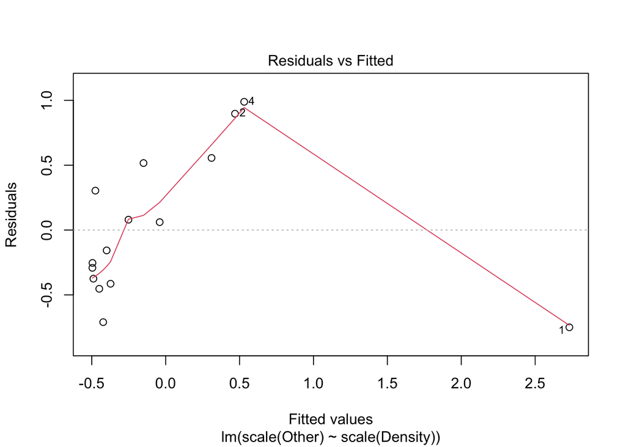

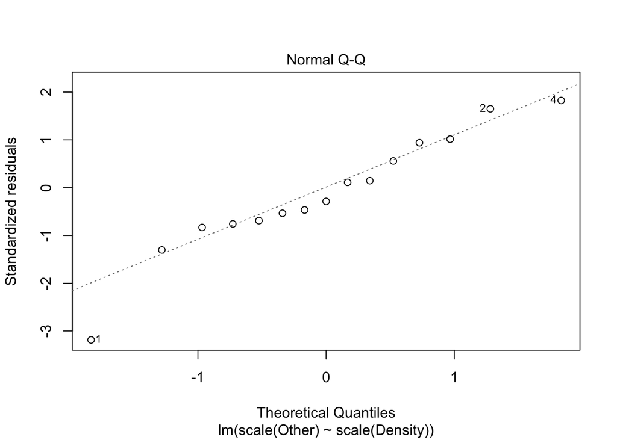

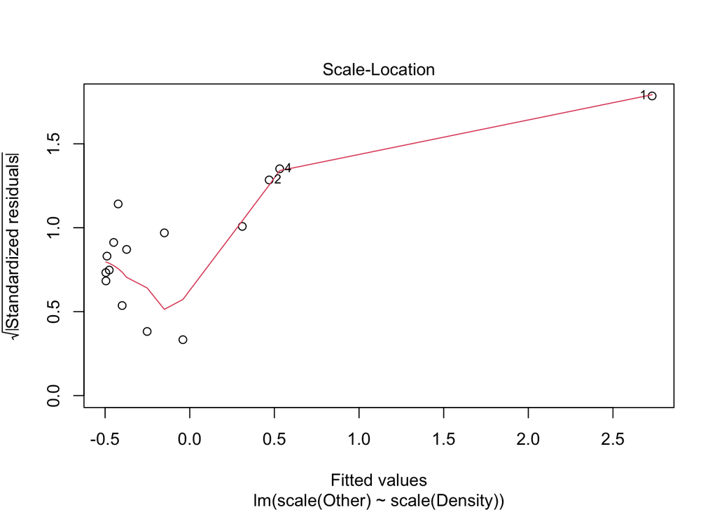

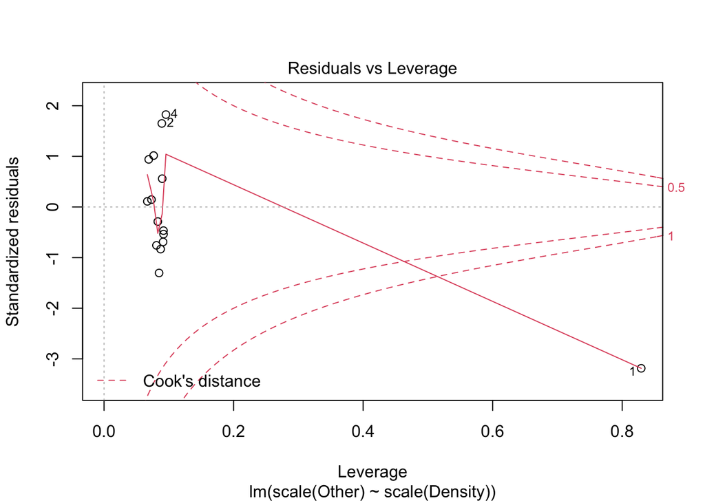

```r
mod <- lm(scale(Other) ~ scale(Density), data = table_clean)

plot(mod)
```

#### Conclusion

From this analysis, we have been able to see a pattern where population size and population density are both related to the frequency of native speakers of other languages than Finnish and Swedish in Finnish municipalities. The underlying reason for these results are beyond the scope of this analysis, but some scholars suggest these trends emerge as a result of increased immigration to larger cities due to the availability of jobs (Chiswick & Miller, 2004). The results of this analysis should be taken carefully due to low sample size and the use of only the largest 15 municipalities in Finland. A more thorough analysis would gather data on all Finnish municipalities and might add other variables to come to more nuanced, insightful conclusions.

## References

Chiswick, B.R. & Miller, P.W. (2004) Where Immigrants Settle in the United States, Journal of Comparative Policy Analysis: Research and Practice, 6:2, 185-197, DOI: 10.1080/1387698042000273479